# 🧠 K-Nearest Neighbors (KNN) Classification Project

- **Author:** Ayoub Majjid
- **Email:** ayoub@majjid.com
- **Portfolio:** majjid.com
- **📂 Repository:** **Repository:** https://github.com/ayoubmajid67/learn/tree/main/ai_data/projects/KNN_Project

### 🎯 **Project Goal**

This project predicts **whether a user will purchase a product** based on demographic data such as:

- **Age**
- **Estimated Salary**
- **Gender**

We use the **K-Nearest Neighbors (KNN)** algorithm — a simple but powerful **machine learning model** that classifies a new point based on its **closest neighbors** in the training data.

### 🏗️ **Notebook Outline**

This notebook demonstrates how to:

1. Load and explore data
2. Preprocess data for ML models
3. Train the KNN classifier
4. Evaluate model performance
5. Visualize decision boundaries
6. Interpret the results visually and statistically

## 🧩 Step 0: Understanding the Idea Behind the KNN Algorithm

Before we start coding, let’s understand **what KNN is and how it works.**

### 🧠 **What is KNN?**

**K-Nearest Neighbors (KNN)** is one of the simplest **supervised machine learning algorithms** used for **classification** and **regression**.

- “Supervised” means it **learns from labeled examples** — data where we already know the correct answer (for example, whether a user bought a product or not).
- KNN doesn’t build an equation or internal model. Instead, it **stores all training examples** and classifies new data by **comparing** it to those examples.

It’s often described as **“learning by analogy.”**

### 📏 **How It Works – Step by Step**

Imagine you have a dataset of users with:

- Age
- Estimated Salary
- Whether they purchased a product (Yes/No)

Now, suppose we meet a **new user** and want to predict if they will buy the product.

Here’s what KNN does:

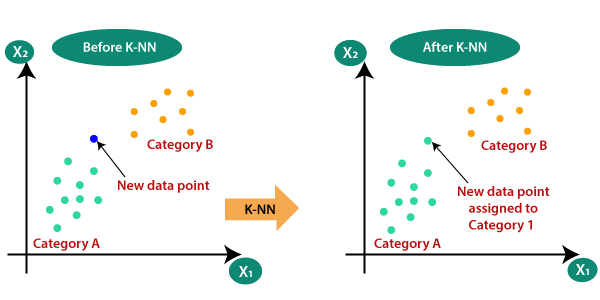

1️⃣ **Compute Distances:**

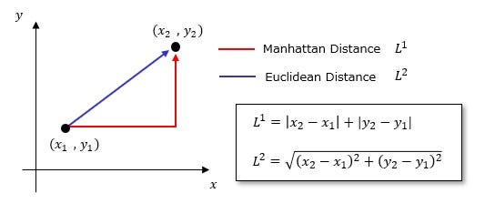

- Measure how “close” the new user is to every user in the training set.
- The most common distance metric is the **Euclidean distance**:

[ d = \sqrt{(x_1 - x_2)^2 + (y_1 - y_2)^2 + ...} ]

This tells us how far points are in multi-dimensional space.

2️⃣ **Find the K Nearest Neighbors:**

- Sort all training samples by distance from the new user.
- Pick the **K closest ones** (for example, the 5 nearest points).

3️⃣ **Voting:**

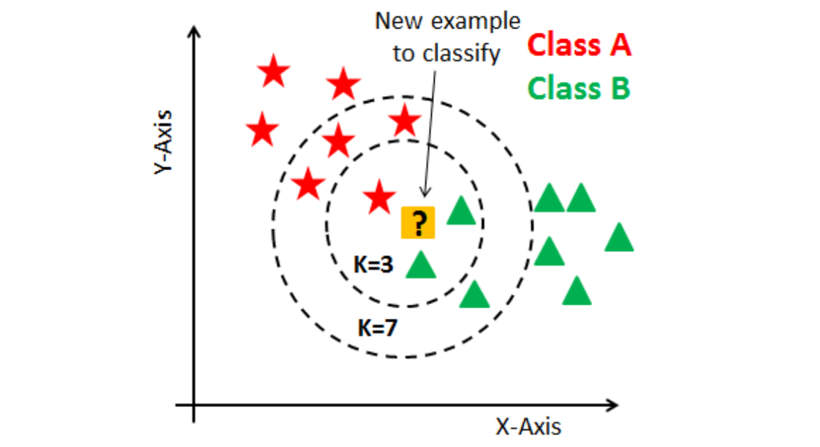

- Each neighbor “votes” for its class (Purchased = 1, Not Purchased = 0).
- The class with the **most votes** becomes the prediction.

Example:

```
K = 5 → [1, 0, 1, 1, 0]
Votes → Purchased = 3, Not Purchased = 2 → Predict Purchased (1)
```

### ⚙️ **Choosing the Right Value of K**

- **Small K** → very sensitive to noise (too local, may overfit).
- **Large K** → smoother, but may ignore local patterns (underfit).
- Typically, we test several values of K and pick the one with the best validation accuracy.

### 🎯 **Why Does KNN Work Well?**

KNN works best when:

- The **data has clear clusters or groups**, like “buyers” and “non-buyers.”
- The **features are scaled**, so no feature dominates distance calculation.
- The **relationship between inputs and output is non-linear** — KNN doesn’t assume any mathematical formula, it adapts to the data shape.

In our case:

- Users with **similar ages and incomes** tend to behave similarly.
- So KNN can easily find patterns based on proximity in feature space.

### 🧩 **KNN in One Sentence:**

> “To predict something new, look at your closest examples and do what most of them do.”

Now that you understand the concept, let’s move on to **data loading and preprocessing** so we can apply this algorithm in practice.

## 🏗️ Step 0.5: Understanding the Project Structure

[output not shown]

### 🔍 Explanation of Each Component

This modular design follows the principle of **separation of concerns**, ensurin each part of the system has a single responsibility.

## **Step-by-Step Guide to Run the Project (Using `venv`)**

1. **Clone the repository**:

[output not shown]

2. **Create a virtual environment**:

```
python -m venv venv
```

3. **Activate the virtual environment**:
- **Windows (cmd):**

```
cmd
venv\Scripts\activate
```

- **Windows (PowerShell):**

```
venv\Scripts\Activate.ps1
```

- **Linux / MacOS:**

```
source venv/bin/activate
```

4. **Install dependencies**:

```
pip install -r requirements.txt
```

5. **Train the model (optional if not already trained)**:

```
python main_train.py
```

```
python main.py
```

- The API will run at `http://127.0.0.1:5000`.
7. **Test the API**:
- **Check API documentation**: Open `docs/api_documentation.pdf`.
- **Postman testing**: Import `docs/KNN_SIG_MODEL.postman_collection.json` into and run the endpoints directly.
- Example request using `curl`:

```
curl -X POST http://127.0.0.1:5000/predict \
     -H "Content-Type: application/json" \
     -d '{"Age": 35, "EstimatedSalary": 50000}'
```

✅ **Tips / Notes**

- Keep your virtual environment **activated** whenever you work on the project.
- Store **all new documentation or API updates** in the `docs/` folder.
- The **Postman collection** is a ready-to-use way to test all endpoints without writing additional code.

## 🧩 Step 0.5: Understanding the Idea Behind the KNN Algorithm

Before we start coding, let’s understand **what KNN is and how it works.**

### 📏 **How It Works – Step by Step**

Imagine you have a dataset of users with:

- Age
- Estimated Salary
- Whether they purchased a product (Yes/No)

Here’s what KNN does:

1️⃣ **Compute Distances:**

- Measure how “close” the new user is to every user in the training set.
- The most common distance metric is the **Euclidean distance**:

[ d = \sqrt{(x_1 - x_2)^2 + (y_1 - y_2)^2 + ...} ]

This tells us how far points are in multi-dimensional space.

2️⃣ **Find the K Nearest Neighbors:**

- Sort all training samples by distance from the new user.
- Pick the **K closest ones** (for example, the 5 nearest points).

3️⃣ **Voting:**

- Each neighbor “votes” for its class (Purchased = 1, Not Purchased = 0).
- The class with the **most votes** becomes the prediction.

Example:

```
K = 5 → [1, 0, 1, 1, 0]
Votes → Purchased = 3, Not Purchased = 2 → Predict Purchased (1)
```

### 🎯 **Why Does KNN Work Well?**

In our case:

- Users with **similar ages and incomes** tend to behave similarly.
- So KNN can easily find patterns based on proximity in feature space.

Now that you understand the concept, let’s move on to **data loading and preprocessing** so we can apply this algorithm in practice.

## ⚙️ Step 0: Import Dependencies and Setup

We’ll import the modules from our `/src` package to keep our project modular and clean.

```python
import sys
import os
# add the project root (parent of notebooks) to the sys.path
# Optional: run once to include project root (parent of notebooks) in sys.path
# """
project_root = os.path.abspath(os.path.join(os.getcwd(), '..'))
if project_root not in sys.path:
    sys.path.append(project_root)
# """


from src.model_train import train_knn, save_model
from src.evaluate import evaluate_model
from src.data_loader import load_data
from src.preprocessing import preprocess_data
from src.visualize import plot_decision_boundary_train_test

import pandas as pd
import matplotlib.pyplot as plt
import seaborn as sns
```

## 📊 Step 1: Load and Explore the Dataset

We start by loading our dataset — **Social_Network_Ads.csv**, which contains information about users and whether they purchased a product after seeing an ad.

```python
 # Load and preprocess data

import pandas as pd

def load_data(path='data/Social_Network_Ads.csv'):
    return pd.read_csv(path)
```

```python
df = load_data("../data/Social_Network_Ads.csv")
df.head()
```

|  | User ID | Gender | Age | EstimatedSalary | Purchased |
| --- | --- | --- | --- | --- | --- |
| 0 | 15624510 | Male | 19 | 19000 | 0 |
| 1 | 15810944 | Male | 35 | 20000 | 0 |
| 2 | 15668575 | Female | 26 | 43000 | 0 |
| 3 | 15603246 | Female | 27 | 57000 | 0 |
| 4 | 15804002 | Male | 19 | 76000 | 0 |

```python
df.info()
```

```
<class 'pandas.core.frame.DataFrame'>
RangeIndex: 400 entries, 0 to 399
Data columns (total 5 columns):
 #   Column           Non-Null Count  Dtype
---  ------           --------------  -----
 0   User ID          400 non-null    int64
 1   Gender           400 non-null    object
 2   Age              400 non-null    int64
 3   EstimatedSalary  400 non-null    int64
 4   Purchased        400 non-null    int64
dtypes: int64(4), object(1)
memory usage: 15.8+ KB
```

### Observations

- **Features:** Age, Gender, EstimatedSalary
- **Target:** Purchased (1 = yes, 0 = no)
- We will later convert categorical values like “Male/Female” into numeric codes.

## ⚙️ Step 2: Data Preprocessing

Machine Learning models can’t understand text or unscaled values — they work best with **numerical, normalized data**.

```python
# Encode, scale, split

from sklearn.model_selection import train_test_split
from sklearn.preprocessing import LabelEncoder, StandardScaler

def preprocess_data(df):
    """
    The column Gender contains text values like "Male" and "Female" (or "Homme", "Femme", depending on the dataset).
    Machine learning algorithms (like KNN) can only work with numbers, not text.
    So we must convert categorical text values → numerical codes.
    Take the Gender column, convert all its values to strings, encode them as numbers (0, 1, etc.), and replace the original column with the numeric version.”
    """

    # Encode gender (text → numeric)
    df['Gender'] = LabelEncoder().fit_transform(df['Gender'].astype(str))

    # Split into features and target
    X = df[['Age', 'EstimatedSalary', 'Gender']].values
    y = df['Purchased'].values

    # Train-test split (75% training, 25% testing)
    X_train, X_test, y_train, y_test = train_test_split(X, y, test_size=0.25, random_state=0)

    # Scale features for KNN (important!)
    sc = StandardScaler()
    X_train = sc.fit_transform(X_train)
    X_test = sc.transform(X_test)

    return X_train, X_test, y_train, y_test
```

```python
X_train, X_test, y_train, y_test = preprocess_data(df)
print(f"Training set: {X_train.shape}, Test set: {X_test.shape}")
```

```
Training set: (300, 3), Test set: (100, 3)
```

### 💡 Why Scaling?

KNN uses **distance** to decide neighbors. Without scaling, a feature like *salary* (which can be in thousands) would dominate over *age*.

## 📈 Step 3: Data Visualization (Before Training)

Before training, let’s visualize how Age and Estimated Salary relate to purchasing decisions.

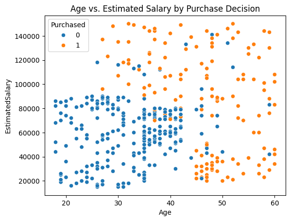

```python
sns.scatterplot(data=df, x='Age', y='EstimatedSalary', hue='Purchased')
plt.title("Age vs. Estimated Salary by Purchase Decision")
plt.show()
```

### 🧠 **Interpretation:**

- Clusters form naturally: younger users with lower income rarely purchase.
- Older or higher-salary users are more likely to purchase.
- This gives intuition for why KNN (a distance-based algorithm) works well here.

## 🧠 Step 4: Train the KNN Model

KNN works by looking at the **K nearest neighbors** of a point and letting them “vote” on its class.

```python
from sklearn.neighbors import KNeighborsClassifier
from sklearn.model_selection import cross_val_score
import numpy as np
import pickle

def train_knn(X_train, y_train, n_neighbors=5, cv_folds=5, verbose=True):
    """
    Train a K-Nearest Neighbors classifier and perform cross-validation.

    Parameters:
    - X_train: Training features
    - y_train: Training labels
    - n_neighbors: Number of neighbors for KNN
    - cv_folds: Number of folds for cross-validation
    - verbose: Whether to print cross-validation results

    Returns:
    - classifier: Trained KNN model
    - cv_scores: Array of cross-validation scores
    - mean_cv_score: Average accuracy across folds
    """

    # Initialize KNN classifier
    classifier = KNeighborsClassifier(n_neighbors=n_neighbors)

    # Perform cross-validation
    cv_scores = cross_val_score(classifier, X_train, y_train, cv=cv_folds, scoring='accuracy')
    mean_cv_score = np.mean(cv_scores)

    if verbose:
        print(f"Cross-validation scores ({cv_folds} folds): {cv_scores}")
        print(f"Average CV accuracy: {mean_cv_score:.2f}")

    # Train KNN on full training set
    classifier.fit(X_train, y_train)

    return classifier, cv_scores, mean_cv_score
```

## ⚙️ Why Use Cross-Validation?

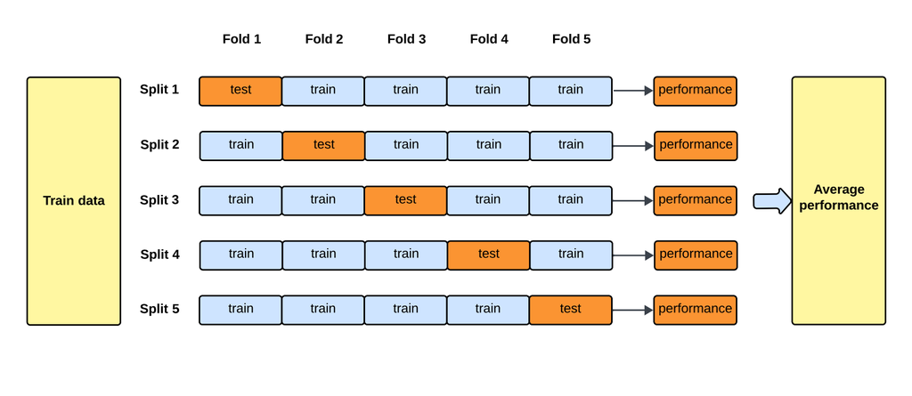

**Cross-validation** is a method to **evaluate model performance more reliably**.

Instead of using a single train-test split:

- We **split the data multiple times** into training and validation sets.
- Train the model on each split and record the performance.
- Calculate the **average performance** → more robust and less biased estimate of accuracy.

**Benefits:**

- Reduces risk of overfitting to a single train-test split
- Gives insight into **model stability**
- Helps choose the **best K** for KNN

```python
model = train_knn(X_train, y_train)
```

[output not shown]

### 💬 Example:

If ( K = 5 ) and among the 5 nearest users, 3 purchased and 2 did not → the model predicts **Purchased = 1**.

## 💾 Step 5: Save the Trained Model

We save the trained KNN model using Python’s `pickle` for reuse in APIs or apps.

```python
save_model(model, '../models/knn_model.pkl')
```

## 📊 Step 6: Evaluate the Model

## 1. Visualize accuracy for each fold in cross-validation.

```
Cross-validation scores (5 folds): [0.88333333 0.88333333 0.85       0.91666667 0.96666667]
Average CV accuracy: 0.90
```

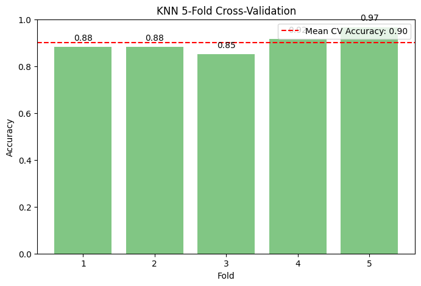

```python
from src.model_train import train_knn
from src.visualize import plot_cv_folds

# Train KNN with cross-validation
model, cv_scores, mean_score = train_knn(X_train, y_train, n_neighbors=5, cv_folds=5)

# Visualize fold accuracies
plot_cv_folds(cv_scores, title="KNN 5-Fold Cross-Validation")
```

## cross validation :interpretation

| Fold | Accuracy |
| --- | --- |
| 1 | 0.8833 |
| 2 | 0.8833 |
| 3 | 0.8500 |
| 4 | 0.9167 |
| 5 | 0.9667 |

**Mean CV Accuracy:** 0.90

### 🔹 Step 1: Examine Each Fold

- **Folds 1 & 2 (0.8833):** Very similar accuracy → model performs consistently on these splits.
- **Fold 3 (0.85):** Slight drop → some harder-to-classify samples present in this fold.
- **Fold 4 (0.9167) & Fold 5 (0.9667):** Excellent performance → these splits were easier for the model.

### 🔹 Step 2: Overall Model Assessment

- **Average accuracy = 0.90** → The model is strong and generalizes well across unseen data.
- **Variance across folds:**
  - Maximum: 0.9667
  - Minimum: 0.85
  - Range = 0.1167 → small variability, indicating **stable performance**.

### 🔹 Step 4: Summary Interpretation

> The KNN model achieves a solid average accuracy of 90% with low variability across folds, demonstrating good generalization while highlighting that a few samples in overlapping feature regions may be misclassified.

## 2. evaluate accuracy and confusion matrix.

We test our model on unseen data and calculate performance metrics.

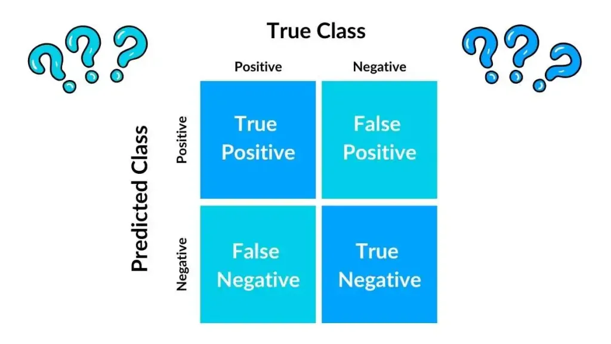

```
Accuracy: 0.93
Confusion Matrix:
 [[64  4]
 [ 3 29]]
```

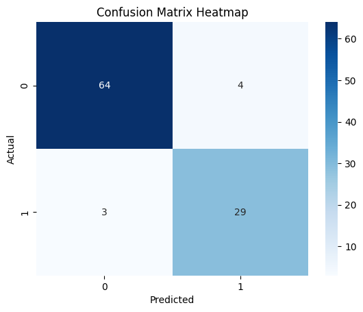

```python
acc, cm = evaluate_model(model, X_test, y_test)
print(f"Accuracy: {acc:.2f}")
print("Confusion Matrix:\n", cm)

# confusion matrix heatmap :
sns.heatmap(cm, annot=True, fmt='d', cmap='Blues')
plt.title("Confusion Matrix Heatmap")
plt.xlabel("Predicted")
plt.ylabel("Actual")
plt.show()
```

### 📊 **Interpreting the Confusion Matrix**

From your documentation:

```
[[64  4]
 [ 3 29]]
```

| Term | Meaning | Count |
| --- | --- | --- |
| **TN (True Negative)** | Correctly predicted non-buyers | 64 |
| **FP (False Positive)** | Incorrectly predicted buyers | 4 |
| **FN (False Negative)** | Missed actual buyers | 3 |
| **TP (True Positive)** | Correctly predicted buyers | 29 |

**Accuracy:** 93% **Precision:** 88% **Recall:** 91% **F1-Score:** 89%

✅ The model performs well — minimal misclassifications, strong generalization.

## 🎨 Step 7: Visualize Decision Boundaries

Now, let’s see **how the model makes its decisions visually**.`plot_decision_boundary_train_test()` function.

### 🧭 **How It Works (from your visualization doc):**

1. **Meshgrid Creation** – a grid of possible (Age, Salary) pairs is generated.
2. **Model Prediction** – KNN predicts each point as “buy” or “not buy.”
3. **Color Regions:**
   - 🟥 **Red:** Model predicts “Not Purchased (0)”
   - 🟩 **Green:** Model predicts “Purchased (1)”
4. **Data Points:**
   - Circles → Training set
   - Squares → Test set

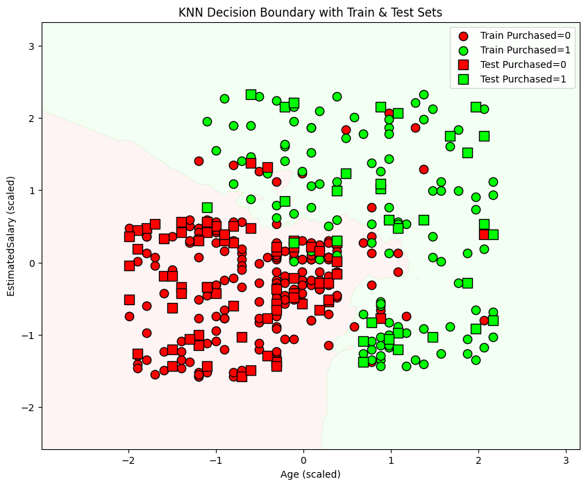

```python
plot_decision_boundary_train_test(model, X_train, y_train, X_test, y_test)
```

### 🧠 **Graph Insights**

- Green and red zones show **decision boundaries** created by KNN.
- Overlapping regions represent **uncertain areas**.
- Misclassified points appear in the “wrong” color zone.
- The model captures complex shapes — a major strength of KNN.

## ✅ Step 8: Conclusion

- The KNN classifier achieves strong performance after scaling and encoding features.
- The decision boundary visualization confirms effective class separation.
- The trained model has been saved for reuse as `models/knn_model.pkl`.

## 🌐 Author Information

- **👨‍💻 Author:** Ayoub Majjid
- **📧 Email:** ayoub@majjid.com
- **🌍 Portfolio:** majjid.com
- **📂 Repository:** https://github.com/ayoubmajid67/learn/tree/main/ai_data/projects/KNN_Project